# Important Course Information

MAT121 - Statistics I

# 1 Introduction

**This is a 100% online, asynchronous course.**

The materials will be delivered in a distance learning format (online) through the [course website] https://pengdsci.github.io/MAT121Online/. You are expected to check this page frequently during this semester for updates and new course materials.

**D2L is used only for weekly assignments (also called quizzes) and midterm and final exam. All weekly topic lists, lecture notes, online practice exercises, module review cards, and interactive statistics learning apps are available exclusively on the course website, not on D2L.**

Four midterm exams will be administered during the semester. For detailed information regarding each exam and the material covered, please refer to the course web pages. The fourth midterm exam and the final exam will be online proctored assessments using a software program **Proctorio**, and will continue to be delivered through D2L.

# 2 What Are You Expected to Do Every Week?

You will complete one module each week, which are structured in the right navigation panel on the course webpage (https://pengdsci.github.io/MAT121/). For each module, follow the suggested workflow below:

- **Review the module-specific page** to see the list of topics and learning resources.
- **Study the module notes**: For each module note, you are expected to
  - study the content to understand the concepts and procedures.
  - watch the embedded short videos in the note to reinforce your understanding.
  - work through the examples (i.e., not simply read the worked out examples ) and check the provided answers.
  - attempt any trial exercises in the lecture notes (if available) and use the appropriate **ISLA apps** to verify your work.
  - practice additional online exercises linked on the module’s webpage.
- **After completing each module**, go to **D2L** to take the **weekly 1uiz**, which covers topics from the module.
- There are **four miterm exams** and a **final exam**. **Each midterm exam** covers previous **three** modules. You can find detailed information about each midterm exam by clicking the link on the right navigation panel of the course web page.
- After finish all three modules, go to D2L to complete the weekly exam the covers all topics from the three modules. There are four weekly exams and a final exam. Each exam has standalone web page detailed information about the exams.
- **To find the weekly quizzes and exams on D2L**,
  - Log in to D2L using your WCU login credentials.
  - Click the course icon (shown below) to access the course page.

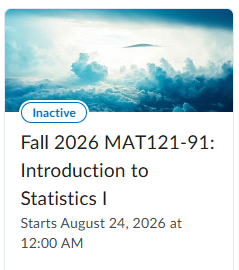

  - From the **Assessments** drop-down menu, select **Quizzes**.
  - Click the link for the appropriate weekly quiz.

# 3 Some Advice

- Start early on weekly materials - **never wait until the last minute**. Procrastination will ruin your progress.
- Practice (**Don’t Just Read**) Examples and Online Multiple-Choice Problems:

  **Tip**: Treat multiple-choice problems as “show-your-work” problems. Solve them step by step, then select the correct answer based on your reasoning. For the **online practice exercises**, only click the “answer” button after completing your work. Use these online resources wisely and responsibly.
- **Using an Appropriate ISLA (Interactive Statistical Learning App)**:

  Use **ISLA** to verify your work and ensure accurate statistical reasoning. If your answers differ from the app’s, carefully review your work to identify mistakes. This method helps debug your thinking and strengthens your understanding.
- **Seeking Help When Needed**:

  If you struggle with certain concepts or examples, note them down and reach out to me or the excellent tutors at MLC. Remember: You can succeed regardless of your prior math experience. Challenges are part of learning - don’t hesitate to ask for help from me, tutors, or peers. Never give up!

# 4 Some Additional Information on Weekly Quizzes and Exams

- **Make-up Exams/Quizzes**
  - **No Make-up Weekly Quizzes** – You have two and a half days to complete the weekly quizzes.
  - **No Make-up Exams** will be offered unless you provide a **university-approved, documented excuse** and notify me **in advance of** the scheduled exam.
- **Additional Information About Weekly Quizzes and Midterm Exams**:
  - Each **weekly quiz** consists of **10–15 multiple-choice questions**.
  - Each **midterm exam** consists of **33–35 multiple-choice questions**.
  - Every student will receive a **different version** of the weekly exam, **all of equal difficulty**.
  - You are allowed **2 attempts per weekly exam**, and only your **highest score** will be recorded.
  - If you **re-attempt** the exam, you must **restart the entire exam** (not just the questions answered incorrectly in the previous attempt).
  - The **answer key** for the master problem set (the basis for quizzes/exams) will be posted on the course webpage every Monday. Use it to prepare for your **final cumulative exam**.
  - If your answers differ from the suggested answer key and you cannot identify the issue, **seek help immediately**. **However, if your answer is very close to one of the given choices, select the closest option, as minor differences may result from rounding errors.**
- Midterm exams are **timed** (see exam-specific pages for details), but you may choose a convenient start time. You may use **any available resources** during the exam.
- **Additional Information about the Proctored Final Exam**
  - The final exam is cumulative, covering all topics discussed during the semester.
  - Unlike the weekly midterm exams, where you could choose your start time, **the final exam is scheduled during the final exam week**. **There is only one available time slot: from 3:30 PM to 5:30 PM** (exact date to be announced). **All students must take the exam simultaneously.**

# 5 Policies, Resources, and Expectations

**Course policies and expectations for exams** are outlined in the syllabus which is posted on the course web page (link is on the top navigation panel).

I provide **comprehensive lecture notes** and have developed **17 interactive statistics learning apps** specifically for this course. Therefore, you do not need to purchase any additional materials or devices. All you need is a commitment to studying the weekly materials and practicing problems through the online exercises.

## 5.1 Textbook (Not Required)

Other sections of this course may require the textbook **Elementary Statistics** by Navidi and Monk (3rd edition). However, this class does not require any textbook. I will provide all necessary material through my lecture notes, which follow the same notational system.

If you would like to keep a copy of the textbook for reference, you are welcome to do so. **If you do not need it, you must opt out of the required eBook. Once you receive the email notification, be sure to take action—otherwise, you will be automatically charged for the electronic textbook.**

## 5.2 Interactive Statistics Learning Apps (ISLA)

I have dedicated significant effort to creating a variety of graphics in the lecture notes and eBook to help you visualize the material wherever possible. Additionally, I’ve developed interactive apps **ISLA** that complement the topics covered in the notes. These apps are organized as standalone sections under the Use of Technology heading to further deepen your understanding of the content.

## 5.3 Calculators and Technologies

**Graphing calculators are not required for this class**, as we only use them occasionally for simple calculations. Instead, you should have a **basic scientific calculator** capable of performing the four basic operations (`+, -, ×, ÷`) and square roots ($\sqrt{x}$).

You can also use the **ISLA** apps as a statistical calculator—both to verify your manual calculations and to check results in the lecture examples (which is how I use them in class).

# 6 Components of Course Grade

Answer keys for each midterm exam will be posted on the course webpage shortly after the exam’s due date.

If necessary, I may adjust midterm and final exam scores based on the class’s overall performance.